# Programación en Lenguajes Estadísticos - 2016374

Programación en Lenguajes Estadísticos - 2016374 Grupo 1 Profesor: Camilo José Torres Jiménez. cjtorresj@unal.edu.co Segundo semestre de 2021

> “El objeto de la educación es preparar a los jóvenes para que se eduquen a sí mismos durante toda su vida.”

> — Robert Hutch

**Sesiones**: Martes y Jueves de 7 a 9 am.

**Enlace Google Meet**: https://meet.google.com/dfa-oxmq-cik

**Atención a estudiantes**: Primero en clase, segundo por medio de Google Classroom, y si se requiere una atención telepresencial adicional, esta podría ser con cita previa en alguna hora del viernes en la tarde o del lunes en la mañana, mediante el mismo enlace de Google Meet del curso (*me tienen que avisar la hora a la que desean que nos conectemos con al menos 24 horas de anticipación*).

**Dedicación de los estudiantes**: mínimo 12 horas a la semana = 4 en clase con el profesor + mínimo 8 fuera de clase.

# 1 Introducción

La acentuada influencia que ha tenido el advenimiento y la evolución del computador en el desarrollo de la Estadística es fehaciente. Hizo posible la utilización de procedimientos cuya estructura teórica y conceptual había sido consolidada mucho antes, y ha permitido con su auxilio gran parte del avance de la disciplina. Por consiguiente, la computación se ha venido convirtiendo en un elemento del cual ya no se puede prescindir en la práctica y en la investigación en Estadística, a tal punto que se ha arraigado como una herramienta inherente al quehacer estadístico.

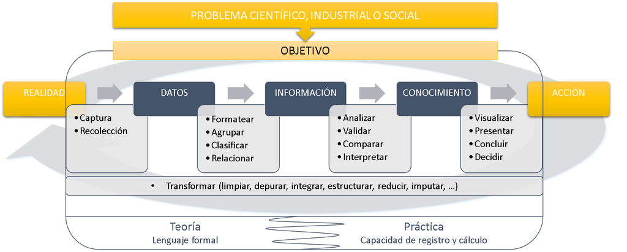

Pero la computación, más allá de ser un ejercicio rutinario para la práctica y de ser un medio extraordinario de investigación y ensanchamiento del cuerpo conceptual de la Estadística, curricularmente es un factor sinérgico que induce y fortalece el pensamiento estadístico.

Como el propósito **NO es convertir al estudiante en usuario exclusivo de paquetes**, sino dotarlo de las herramientas necesarias para un apropiado desempeño académico, se procura entonces generar en el estudiante habilidades de programación de computadores que le permitan modificar programas o desarrollar aplicaciones singulares de distinta complejidad, implementadas algorítmicamente mediante uno u otro lenguaje de programación. Adicionalmente, el cumplimiento de este propósito garantiza que se desarrolle la capacidad de usar y entender adecuadamente *software* creado por otros para aspectos de gran relevancia en el quehacer estadístico, como lo son la transformación, el procesamiento y el análisis de datos, entre otros. De esta manera, cuando en las demás asignaturas aprendan los comandos y las salidas de una u otra herramienta de análisis estadístico, los estudiantes entenderán qué es lo que realmente hacen dichos comandos, en qué otros escenarios los podrían utilizar, qué debilidades tienen y cómo podrían modificarlos.

El cursar una asignatura que se encamine hacia el desarrollo de capacidades de programación de computadores, es un requisito que se debe exigir en la formación de un Estadístico y que en consecuencia debe ser obligatoria; sin embargo, la flexibilidad de la estructura curricular le imprime un carácter opcional. El estudiante puede optar entre varias posibilidades para cumplir el requisito, cursando una asignatura con la carrera de Ingeniería de Sistemas (Programación de computadores), con la Carrera de Matemáticas (Programación y métodos numéricos) o con la Carrera de Estadística (Programación en Lenguajes Estadísticos). Las asignaturas de esta agrupación difieren en su contenido y propósitos particulares, pero son coherentes temáticamente, puesto que coinciden en ser un primer curso para estimular el desarrollo de capacidades de programación de computadores.

Es así que, además de presentar los fundamentos básicos de la programación, la asignatura **Programación en Lenguajes Estadísticos** debe propender por la generación de un espacio para estimular la creatividad del estudiante ante problemas propios de la estadística que requieren de soluciones algorítmicas. Dichos fundamentos básicos y dicha creatividad, así como la capacidad de programar competentemente y aplicando buenas prácticas de programación, son necesarios sobretodo en temas como el de estructuras de datos, sistemas de información, computación estadística, aprendizaje de máquinas e inteligencia artificial y manejo de datos a gran escala (*big data*). Esto sin contar la necesidad de que exista un segundo curso de programación que vaya más allá de los fundamentos básicos, y que junto con un curso de sistemas de información, permita que los estudiantes estén en capacidad de participar en cualquier parte del desarrollo de una aplicación informática con una fuerte componente estadística, por ejemplo en el caso de aplicaciones web resultantes de un análisis estadístico en línea (*online*) de cierto problema o situación.

# 2 Objetivo de formación

Incentivar la capacidad de abstraer problemas relacionados con la estadística y de formular su solución, por medio del diseño de algoritmos y de su implementación en un lenguaje de programación.

# 3 Objetivos pedagógicos

El estudiante que curse la asignatura y cumpla con las exigencias académicas, podrá:

1. Proponer un procedimiento lógico para resolver un problema relacionado con el quehacer estadístico.
2. Diseñar soluciones algorítmicas para la resolución de problemas mediante el uso de un computador.
3. Implementar soluciones algorítmicas totalmente funcionales en al menos dos lenguajes de programación distintos.
4. Desarrollar o modificar funciones o programas de distinta complejidad.
5. Proponer y utilizar estructuras de datos compuestas en las soluciones algorítmicas que desarrolle.

# 4 Contenido

A. PRELIMINARES:

1. Introducción a los lenguajes de marcado y los cuadernos computacionales (*notebooks*).
   1. Generalidades acerca de Latex.
   2. Generalidades acerca de Markdown.
   3. Generalidades acerca de Jupyter Notebook.
   4. Generalidades acerca de R Markdown.
2. Introducción a los computadores y los lenguajes de programación.
   1. Breve historia.
   2. Organización de un computador (*Hardware* y *Software*).
   3. El lenguaje del computador.
   4. Programación de computadores y lenguajes de programación.
   5. Paradigmas de programación.
3. Metodología de la programación.
   1. Resolución de problemas mediante el uso de computadores y sus fases.
   2. Algoritmos: Diseño, características y representaciones.

B. UTILIZANDO UN PRIMER LENGUAJE DE PROGRAMACIÓN (Python):

1. Elementos básicos de un programa.
   1. Documentación interna (comentarios).
   2. Identificadores, variables y constantes.
   3. Instrucciones y expresiones.
   4. Tipos de variables primitivos, simples o básicos.
   5. Operadores básicos.
   6. Funciones internas básicas.
2. Estructuras de control.
   1. Estructuras de selección o decisión.
   2. Estructuras de repetición, iterativas o cíclicas.
3. Introducción a los subprogramas.
   1. Creación de funciones propias.
   2. Ambito de las variables.
   3. Funciones anónimas.
   4. Funciones de orden superior.
   5. Recursión.
4. Introducción a la programación orientada a objetos.
   1. Clases, objetos, atributos y métodos.
   2. Métodos estáticos.
   3. Encapsulamiento y principio de ocultación.
   4. Herencia.
   5. Polimorfismo y sobrecarga de operadores.
5. Introducción al manejo de excepciones o errores.
   1. Captar una excepción o error.
   2. Encender un excepción o error.
   3. Creación de excepciones o errores propios.
6. Introducción a estructuras para colecciones de datos.
   1. Cadenas como secuencia de caracteres.
   2. Tuplas, listas y rangos.
   3. Conjuntos.
   4. Diccionarios.
   5. Iterables e iteradores.
7. Lectura y escritura de archivos de texto plano.
8. Módulos y paquetes.
   1. Introducción a la creación de módulos y paquetes propios.
   2. Generalidades acerca de algunos módulos y paquetes de inicial potencial interés para un estadístico.

C. UTILIZANDO UN SEGUNDO LENGUAJE DE PROGRAMACIÓN (R):

1. Aprendizaje de segundo lenguaje de programación.
   1. Identificación de particularidades, similitudes y diferencias.
   2. Elementos básicos, estructuras de control, subprogramas, manejo de archivos de texto plano y estructuras para colecciones de datos (cadenas, vectores, factores, matrices, arreglos, listas y *data frames*).
2. Generalidades acerca de algunas funciones de inicial potencial interés para un estadístico, incluyendo la generación de gráficos.

# 5 Acerca del contenido

Dado el impacto que tiene en el contenido de la asignatura, es importante volver a resaltar que este curso NO se trata de aprender a manejar uno u otro “software estadístico”, es decir NO se trata de aprender un listado de comandos, funciones, módulos o paquetes. Esta asignatura se trata acerca de aprender a programar, es decir que se trata acerca de estar en capacidad de diseñar e implementar comandos, funciones, módulos o paquetes propios. Además, si se tiene la capacidad de desarrollar un programa propio desde cero, entonces también se tiene la capacidad de entender y modificar uno desarrollado por otras personas.

En cuanto a los lenguajes de programación para la asignatura:

- Entre los lenguajes con soporte para la programación orientada a objetos como Python, Java y C++ (puestos 2, 3 y 4, respectivamente, según el índice TIOBE https://www.tiobe.com/tiobe-index/ de agosto 2021), se selecciona a Python como primer lenguaje de programación del curso (y de los estudiantes, bajo la premisa de que ninguno de ellos sabe programar). Python https://www.python.org/ es reconocido como un muy buen lenguaje para empezar a programar, hoy en día tiene una gran acogida y desarrollo, es bastante flexible y con frecuencia es utilizado para lo que recientemente se ha denominado como “ciencia de datos”.

  Se considera que los módulos y paquetes `math`, `numpy`, `scipy`, `sympy` y `rpy2` serían los primeros que los estudiantes deberían aprender y una pequeña revisión de los mismos se puede hacer en la presente asignatura. Existen otros paquetes importantes como: `pandas`, `matplotlib`, `seaborn`, `plotly`, `dash` y `jupyter-dash`, que no alcanzarían a entrar dentro del temario y se esperaría que en aquellas asignaturas que requieran el uso de estos u otros paquetes se haga la revisión de los mismos. Si se crea un segundo curso de programación, allí se podría incluir la creación de gráficos dinámicos, aplicaciones web y tableros de control (paquetes `plotly`, `dash` y `jupyter-dash`).
- Entre los lenguajes de programación que al mismo tiempo son herramientas informáticas matemático/estadísticas como R, Matlab, SAS y Julia (puestos 14, 17, 21 y 26, respectivamente, según el índice TIOBE de agosto 2021), se selecciona a R como segundo lenguaje de programación del curso. Por su parte, R https://cran.r-project.org/ es actualmente y sin lugar a dudas el principal *software* estadístico de uso libre y desarrollo colaborativo.

  En R existen demasiadas funciones y paquetes de potencial interés para los estadísticos. Se sugiere que los estudiantes por fuera del curso estudien por su cuenta los paquetes `plotly`, `dash`, `shiny` y los que hacen parte del “tidyverse” https://www.tidyverse.org/packages/, entre otros. Además, en cada asignatura de la carrera se debería enseñar a los estudiantes el uso de las funciones y paquetes en R asociados al respectivo contenido de esa asignatura.

Por otra parte, para los estadísticos es particularmente importante el producir reportes, presentaciones, informes, trabajos o similares. En general, estos documentos contendrán tanto texto y fórmulas matemáticas, como tablas y gráficos resultantes de ejecutar una serie de comandos o instrucciones en algún *software*. Teniendo en cuenta lo anterior, se considera importante para esta asignatura el poder cubrir, al menos en parte, el manejo de algunos cuadernos computacionales (*notebooks*) que permitan ejecutar e integrar, con el resto del documento, el código que genera las tablas, gráficos y otros (Jupyter Notebook https://jupyter.org/ y R Markdown https://rmarkdown.rstudio.com/). Así mismo, es necesario aprender un poco acerca de ciertos lenguajes de marcado que permiten incluir adecuadamente fórmulas matemáticas, además de controlar el formato del contenido del documento o *notebook* (Latex https://www.latex-project.org// y Markdown https://daringfireball.net/projects/markdown/).

# 6 Metodología

Se espera una labor constante, integrada, con una retroalimentación mutua, y centrada en el trabajo del estudiante en favor de su proceso de aprendizaje. Dicho proceso deberá tener como bases la motivación intrínseca y la responsabilidad del estudiante. El trabajo del docente será de ayuda, acompañamiento y guía. En las clases revisaremos principalmente las ideas y los conceptos detrás de cada tema, tratando de hacer la mayor cantidad de ejemplos en clase. Como a programar se aprende programando, todos los ejercicios que se propongan en clase deberán ser realizados por el estudiante (*recordar que su dedicación fuera de clase deber ser de mínimo 8 horas a la semana*), con retroalimentación del profesor cuando así lo requieran.

Los ejemplos y los ejercicios (en general, los problemas a resolver) estarán relacionados con tópicos de los cursos de estadística descriptiva, probabilidad, cálculo y álgebra lineal. Lo anterior teniendo en cuenta que **Programación en Lenguajes Estadísticos** es una asignatura que se sugiere sea tomada en el tercer semestre de la Carrera de Estadística, junto con: Álgebra Matricial, Probabilidad y Calculo Vectorial.

# 7 Programación

**Semana 1**

- Presentación del curso.
- Introducción a los computadores y los lenguajes de programación.

**Semanas 2 y 3**

- Metodología de la programación.

*Fin de tema para primera calificación*

**Semanas 4 y 5**

- Elementos básicos de un programa (Python).
- Estructuras de control (Python).

**Semana 6**

- Introducción a los subprogramas (Python).

*Fin de tema para segunda calificación*

**Semanas 7 y 8**

- Introducción a la programación orientada a objetos (Python).

**Semana 9**

- Introducción al manejo de excepciones o errores (Python).

*Fin de tema para tercera calificación*

**Semanas 10 y 11**

- Introducción a estructuras para colecciones de datos (Python).
- Lectura y escritura de archivos de texto plano (Python).

**Semanas 12**

- Módulos y paquetes (Python).

*Fin de tema para cuarta calificación*

**Semanas 13 a 15**

- Aprendizaje de segundo lenguaje de programación (R).

*Fin de tema para quinta calificación*

**Semana 16**

- Generalidades acerca de algunas funciones de potencial interés para un estadístico (R).

**Durante todo el semestre de manera transversal**

- Introducción a los lenguajes de marcado (Latex y Markdown) y los cuadernos computacionales *notebooks* (Jupyter y R Markdown).
- Ejemplos y ejercicios relacionados con estadística descriptiva, probabilidad, cálculo y álgebra lineal.

# 8 Calificación

Evaluar y asignar una calificación no es lo mismo: “La evaluación es un proceso. La calificación es un suceso”.

- Evaluar debe ser un **proceso constante** en el que el **estudiante, responsable de su aprendizaje,** analiza su desempeño e identifica aquello que “comprende” y “hace correctamente” y aquello que no, dicho proceso es apoyado por una retroalimentación que puede provenir de sí mismo, de sus compañeros o del docente.
- La asignación de una calificación corresponde a una medición, ponderación o gradación que es responsabilidad del docente.

| Actividad |  |
| --- | --- |
| Primera | Semana 4 del semestre académico |
| Segunda | Semana 7 del semestre académico |
| Tercera | Semana 10 del semestre académico |
| Cuarta | Semana 13 del semestre académico |
| Quinta | Semana 16 del semestre académico |

- En cada caso se decidirá e informará si la actividad a realizar conducente a una calificación será un examen para resolver o un trabajo para entregar, en ambos casos podría incluir una exposición oral individual. **Un trabajo o examen que no cumpla con las condiciones o restricciones establecidas para el mismo (de modo, forma, tiempo, etc.) tendrá una calificación de 0 sobre 5**.

# 9 Bibliografía

**Latex**

Un clásico:

- R. De Castro Korgi, *El universo LATEX*. Universidad Nacional de Colombia, 2003 [Online]. Disponible en: http://ciencias.bogota.unal.edu.co/menu-principal/publicaciones/biblioteca-digital/matematicas/

Consulta rápida:

- Wikibooks, *LaTeX — Wikibooks, The Free Textbook Project*. 2021 [Online]. Disponible en: https://en.wikibooks.org/w/index.php?title=LaTeX&oldid=3790790

**Markdown**

- M. Cone, *The Markdown Guide*. Independently Published, 2020 [Online]. Disponible en: https://www.markdownguide.org/
- J. MacFarlane, *CommonMark Spec Version 0.30*. 2021 [Online]. Disponible en: https://spec.commonmark.org/current/

**Jupyter**

- Jupyter Team, *Jupyter Notebook Documentation*. 2021 [Online]. Disponible en: https://jupyter-notebook.readthedocs.io/en/stable/
- Google Research, *Welcome to Colaboratory*. 2021 [Online]. Disponible en: https://colab.research.google.com/notebooks/intro.ipynb

**R Markdown**

- Y. Xie, J. J. Allaire, y G. Grolemund, *R Markdown: The Definitive Guide*. CRC Press, 2020 [Online]. Disponible en: https://bookdown.org/yihui/rmarkdown/

**Metodología, lógica o fundamentos de programación**

Sin atarse a un lenguaje de programación en particular:

- L. Joyanes Aguilar, *Fundamentos de programación: algoritmos, estructura de datos y objetos*. McGraw Hill, 2020 [Online]. Disponible en: http://www.ebooks7-24.com.ezproxy.unal.edu.co/?il=10409&pg=1

Metodología, lógica, diseño y tres lenguajes de programación en un solo libro:

- L. Joyanes Aguilar y I. Zahonero Martínez, *Programación en C, C++, Java y UML*. McGraw-Hill, 2014 [Online]. Disponible en: http://www.ebooks7-24.com.ezproxy.unal.edu.co/?il=291&pg=1

**Python**

Libro guía del curso para Python:

- J. Hunt, *A Beginners Guide to Python 3 Programming*. Springer International Publishing, 2019 [Online]. Disponible en: https://link-springer-com.ezproxy.unal.edu.co/book/10.1007/978-3-030-20290-3

Si se va directo a la fuente:

- Python Software Foundation, *Python for Beginners*. 2021 [Online]. Disponible en: https://www.python.org/about/gettingstarted/

Tutoriales y consulta rápida:

- W3Schools, *Python Tutorial*. 2021 [Online]. Disponible en: https://www.w3schools.com/python/default.asp

**R**

R como lenguaje de programación:

- R Core Team, *R Language Definition*. 2021 [Online]. Disponible en: https://cran.r-project.org/doc/manuals/r-release/R-lang.html

Introducción a R, un poco más como “software estadístico” que como lenguaje de programacion:

- W. N. Venables, D. M. Smith, y R Core Team, *An Introduction to R*. 2021 [Online]. Disponible en: https://cran.r-project.org/doc/manuals/r-release/R-intro.html

Si se desea profundizar un poco acerca de R como lenguaje de programación:

- H. Wickham, *Advanced R*. CRC Press, 2014 [Online]. Disponible en: https://adv-r.hadley.nz/

**Algoritmos, técnicas o métodos numéricos**

Libro clásico que muy frecuentemente sirve como libro de consulta (las soluciones están implementadas en C++, pero las explicaciones se entienden sin importar el lenguaje de programación):

- W. H. Press, S. A. Teukolsky, W. T. Vetterling, y B. P. Flannery, Numerical Recipes with Source Code CD-ROM 3rd Edition: The Art of Scientific Computing. Cambridge University Press, 2007 [Online]. Disponible en: http://numerical.recipes/book/book.html